# 2-fuel-consumption

## Fuel

- Fuels come in different forms
- Here we refer to solid, liquid, and gaseous hydrocarbons
- They serve different purposes
  - Electricity production
  - Transport
  - Production of different chemicals
- Fossil fuels are stored solar energy from millions of years ago

## Fuels

- Chemical formula (simplification)
  - Natural gas: CH$_4$
  - Oil: CH$_2$
  - Coal: CH
- Combustion reaction:
  - CH2 + 2 O2 = CO2 + H2O
- Combustion energy [link](https://en.wikipedia.org/wiki/Heat_of_combustion):
  - 400 kJ/mol for each carbon atom
  - 100 kJ/mol for each hydrogen atom

## Exercise

Calculate the CO2 emission per unit energy of methane, oil, and coal combustion. Required information include:

- Molar mass of CO2: 44 g/mol
- Molar mass of C: 12 g/mol
- Molar mass of H: 1 g/mol

```python
# Solution
C = 400. # kJ/mol
H = 100. # kJ/mol
M_C = 12. # g/mol
M_H = 1.  # g/mol
M_CO2 = 44. # g/mol

Heat_comb_CH4 = C+4*H # kJ/mol
Heat_comb_oil = C+2*H # kJ/mol
Heat_comb_coal = C+H  # kJ/mol

CO2_per_heat_CH4 = M_CO2/Heat_comb_CH4 # g/kJ
CO2_per_heat_oil = M_CO2/Heat_comb_oil # g/kJ
CO2_per_heat_coal = M_CO2/Heat_comb_coal # g/kJ
```

## Fuels

Energy density and CO2 emission of coal, oil, and methane:

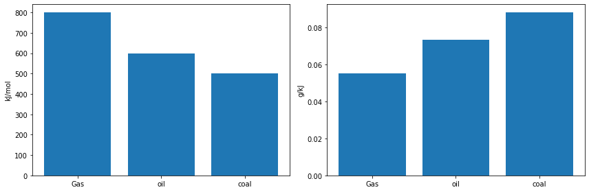

```python
import matplotlib.pyplot as plt
fuels = ('Gas', 'oil', 'coal')
plt.figure(figsize=(12,4))
plt.subplot(1,2,1)
plt.bar(fuels,[Heat_comb_CH4, Heat_comb_oil, Heat_comb_coal])
plt.ylabel('kJ/mol')
plt.subplot(1,2,2)
plt.bar(fuels, [CO2_per_heat_CH4, CO2_per_heat_oil, CO2_per_heat_coal])
plt.ylabel('g/kJ');
plt.tight_layout()
```

## Fuels

Assumption:

- driving from houses to the agricultural lands 15 km/day
- Shipping -The closest large country is 500 km away
  - import/export of stuff in large containers
- Flights
  - two flights per day to nearby islands/lands (300 km)
  - one flight per day to/from the closest large country

## Fuel consumption

Automobiles

- Trucks: 12 L/(100 km)
- Cars: 8 L/(100 km)
- Average: 10 L/(100 km)
- [MacKay](http://www.withouthotair.com/c3/page_29.shtml) 12 km/L

[Ships](https://withouthotair.com/c15/page_91.shtml)

- 0.015 kWh/(tonne.km)

[Trucks](https://withouthotair.com/c15/page_91.shtml)

- 1 kWh/(tonne.km)

Airplanes

- 37-42 kWh/(100 p.km)

## Fuel consumption for electricity

Power plants (with the possibility of being replaced by renewable electricity)

| Power plant | Natural gas combined cycle | Pulverized coal | IGCC |
| --- | --- | --- | --- |
| Efficiency (%) | 55-63 | 25-30 | 35-45 |

[figure not shown]

## Exercise 1

Yesterday, you calculated the heat requirement of the island. Now, assume that all the heat is supplied by the combustion of fossil fuels.

- What is the CO2 emission of heating per person per day?

Estimate the total fuel consumption in the transportation sector of the island.

- What is the fuel requirement per person per day in cubic meters of oil, and kWh?
- What is the CO2 emission of the transportation sector per person per day?

## Exercise 2

- Estimate the overall electricity consumption of the island.
- Assume that warming is done by using electrical heaters. What is the extra heat that is required in the island?
- Current CO2 emission of the electricity production in the island.
- CO2 emission of the new scenario of coal power plant + renewable electricity.